# ECE 176 Assignment 2: Linear Regression

### Plot the Accuracies vs epoch graphs

```python
import matplotlib.pyplot as plt


def plot_accuracies(train_acc, val_acc, test_acc):
    # Plot Accuracies vs Epochs graph for all the three
    epochs = np.arange(0, int(num_epochs_total / epochs_per_evaluation))
    plt.ylabel("Accuracy")
    plt.xlabel("Epoch/10")
    plt.plot(epochs, train_acc, epochs, val_acc, epochs, test_acc)
    plt.legend(["Training", "Validation", "Testing"])
    plt.show()
```

```python
# Run training and plotting for default parameter values as mentioned above
t_ac, v_ac, te_ac, weights = train(learning_rate, weight_decay)
```

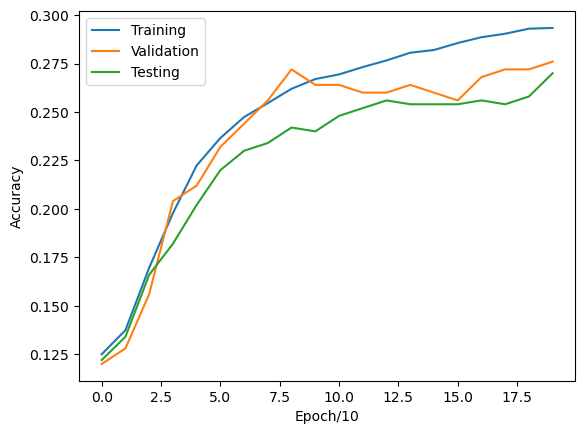

```python
plot_accuracies(t_ac, v_ac, te_ac)
```

### Try different learning rates and plot graphs for all (20%)

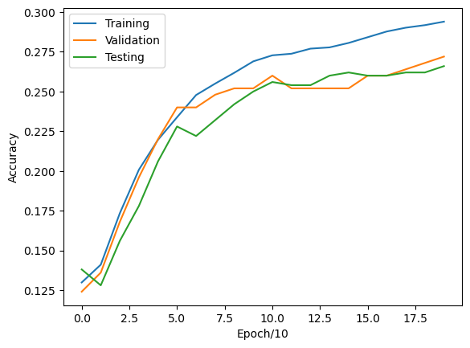

```
Current learning rate:  0.0001
```

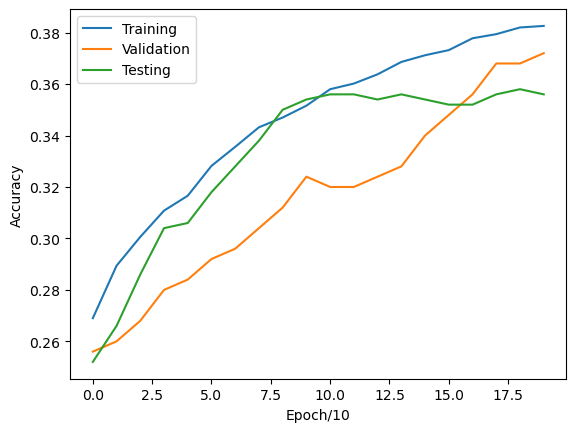

```
Current learning rate:  0.001
```

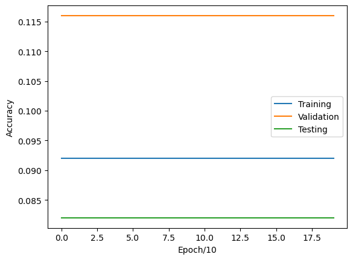

```
Current learning rate:  0.01
Best Accuracy:  0.372
Best learning rate:  0.001
```

```python
# Initialize the best values
best_weights = weights
best_learning_rate = learning_rate
best_weight_decay = weight_decay

# TODO
# Repeat the above training and evaluation steps for the following learning rates and plot graphs
# You need to try 3 learning rates and submit all 3 graphs along with this notebook pdf to show your learning rate experiments
learning_rates = [0.0001, 0.001, 0.01]
weight_decay = 0.0  # No regularization for now

# FEEL FREE TO EXPERIMENT WITH OTHER VALUES. REPORT OTHER VALUES IF THEY ACHIEVE A BETTER PERFORMANCE

# for lr in learning_rates: Train the classifier and plot data
# Step 1. train_accu, val_accu, test_accu = train(lr, weight_decay)
# Step 2. plot_accuracies(train_accu, val_accu, test_accu)
best_accuracy = 0.0

for learning_rate in learning_rates:
    # TODO: Train the classifier with different learning rates and plot
    train_accu, val_accu, test_accu, weights = train(learning_rate, weight_decay)


    # plot accuracies
    plot_accuracies(train_accu, val_accu, test_accu)

    print("Current learning rate: ", learning_rate)

    # update values
    current_best_accuracy = max(val_accu)
    if current_best_accuracy > best_accuracy:
        best_accuracy = current_best_accuracy
        best_weights = weights
        best_learning_rate = learning_rate

print("Best Accuracy: ", best_accuracy)
print("Best learning rate: ", best_learning_rate)
```

#### Inline Question 1.

Which one of these learning rates (best_lr) would you pick to train your model? Please Explain why.

#### Your Answer:

I would choose a learning rate of 0.001 as it shows a significant improvement in accuracy over epochs for training, validation, and testing. The curves are smooth and the validation accuracy is the highest among the three, so there's good generalization. 0.01 shows poor performance with almost no learning happening based on the flat lines for training, validation, and testing accuracy. A learning rate of 0.0001 shows improvement over 0.01, but the accuracy is lower than the second chart's learning rate of 0.001.